# EP05 Grupo 6

2024-10-24

## Pregunta ¿Existen diferencias en el tiempo de resolución de cubos Megaminx entre participantes de Uruguay, Perú y Colombia?

- **Hipótesis nula:** No existen diferencias en el tiempo de resolución de cubos Megaminx entre participantes de Uruguay, Perú y Colombia.
- **Hipótesis alternativa:** Existen diferencias en el tiempo de resolución de cubos Megaminx entre participantes de Uruguay, Perú y Colombia.
- Verificación de condiciones
1. La escala con que se mide la variale dependiente tiene las propuedades de una escala de intervalos iguales.
- Lo anterior si se cumple, ya que el tiempo de resolución de cubos Megaminx es una variable continua que se mide en segundos, y se puede considerar que la diferencia entre 1 y 2 segundos es la misma que entre 2 y 3 segundos.
2. Las k muestras son obtenidas de manera aleatoria e independiente desde las poblaciones de origen.
- Por el mismo enunciado se menciona que los datos son obtenidos de una competencia de cubos Rubik, por lo que se puede considerar que los datos son obtenidos de manera aleatoria e independiente.
3. Se puede suponer que las poblaciones de origen siguen una distribución normal.
- Para lo anterior se realizara un código Q-Q plot para verificar si los datos siguen una distribución normal:

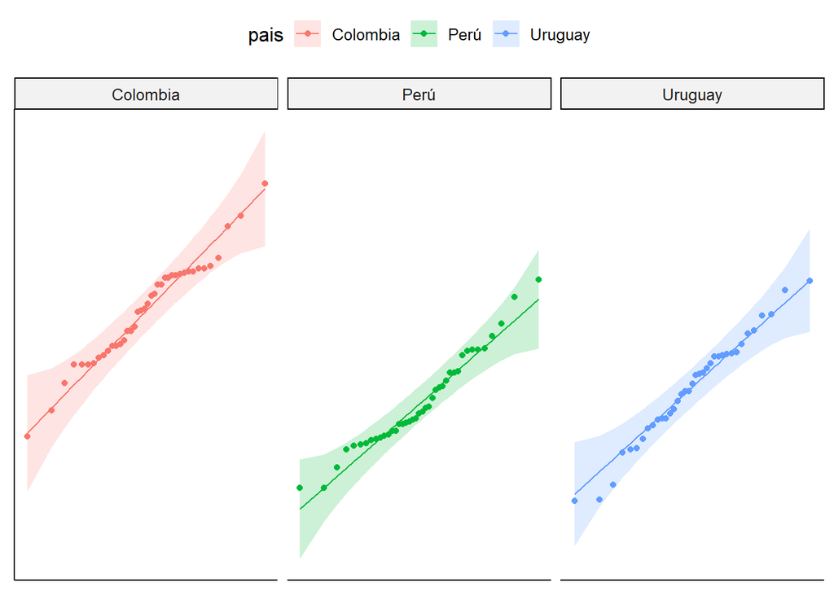

```r
# Obtengo los datos
datos <- read.csv2("EP05 Datos.csv")

# Recopilo los datos de tiempo de resolución de cubos Megaminx, dejandolos en formato largo
datos <- datos %>% filter(tipo == "Megaminx") %>% select(pais, tiempo) %>% filter(pais == "Uruguay" | pais == "Perú" | pais == "Colombia")

# Realizo un Q-Q plot
g <- ggqqplot(datos, x = "tiempo", y = "pais", color = "pais") + facet_wrap(~ pais)
g <- g + rremove("x.ticks") + rremove("x.text")
g <- g + rremove("y.ticks") + rremove("y.text")
g <- g + rremove("axis.title")
print(g)
```

Podemos notar por el gráfico que los datos siguen razonablemente una distribución normal.

4. Si las muestras provienen de más de una población, estas tienen la misma varianza.
- Para lo anterior calcularemos la varianza de cada grupo, y obtendremos la minima y máxima varianza para dividir la varianza máxima entre la mínima y verificar si es menor a 1.5.

```r
# Calculo la varianza de cada grupo
varianza <- datos %>% group_by(pais) %>% summarise(varianza = var(tiempo))

# Obtengo la varianza máxima y mínima
varianza_max <- max(varianza$varianza)
varianza_min <- min(varianza$varianza)

# Obtengo la relación entre la varianza máxima y mínima
relacion <- varianza_max / varianza_min

# Muestro los resultados
print(relacion)
```

```
## [1] 1.27483
```

Como la relación es menor a 1.5, se puede considerar que las varianzas son iguales.

Con lo anterior, se cumplieron todas las condiciones para realizar un ANOVA de un factor.

```r
alfa <- 0.05

# Muestro los primeros datos
head(datos)
```

```
##       pais tiempo
## 1     Perú  75.57
## 2  Uruguay  76.12
## 3 Colombia  76.20
## 4     Perú  75.14
## 5     Perú  75.43
## 6     Perú  76.29
```

```r
# Hago la prueba de ANOVA
modelo <- aov(tiempo ~ pais, data = datos)
print(summary(modelo))
```

```
##              Df Sum Sq Mean Sq F value   Pr(>F)
## pais          2  15.13   7.564   37.73 2.52e-13 ***
## Residuals   115  23.05   0.200
## ---
## Signif. codes:  0 '***' 0.001 '**' 0.01 '*' 0.05 '.' 0.1 ' ' 1
```

Del resultado obtenido por la prueba ANOVA, se obtuvo un p-value 2.52e-13, valor claramente menor a nuestro valor de significancia, por lo cual se rechaza la hipótesis nula en favor de la hipótesis alternativa, por ende se procederá a hacer un procedimiento post_hoc, lo anterior para determinar entre cuales paises existen diferencias significativas.

```r
# Utilizo el post_hoc de Tukey
post_hoc <- TukeyHSD(modelo,
                     "pais",
                     ordered = TRUE,
                     conf.level = 1 - alfa)


print(post_hoc)
```

```
##   Tukey multiple comparisons of means
##     95% family-wise confidence level
##     factor levels have been ordered
##
## Fit: aov(formula = tiempo ~ pais, data = datos)
##
## $pais
##                       diff        lwr       upr     p adj
## Uruguay-Perú     0.1248649 -0.1161930 0.3659227 0.4380439
## Colombia-Perú    0.8080000  0.5717416 1.0442584 0.0000000
## Colombia-Uruguay 0.6831351  0.4406522 0.9256181 0.0000000
```

Con el resultado de post_hoc Tukey, se obtuvo que el p-value entre: * Uruguay-Perú: 0.4380439 * Colombia-Perú: 0 * Colombia-Uruguay: 0

Por lo que se puede concluir que existen diferencias significativas entre Colombia y Perú, y entre Colombia y Uruguay, pero no entre Uruguay y Perú.